# Homework 03

Annika Godines

2024-02-08

# Question 1

## Part A

What creatinine clearance rate should we expect for a 55-year-old?

```
## [1] "Predicted creatinine clearance rate for a 55-year-old: 113.72 mL/minute"
```

The estimated creatinine clearance rate for a 55-year-old is 113.72 mL/minute. This is using a linear regression model using age an a predicting variable. This estimation is important because it can help indicate the expected kidney health measurement for an individual of this age.

## Part B

How does creatinine clearance rate change with age?

```
## [1] "The change in creatinine clearance rate per year is: -0.62 mL/minute per year"
```

As shown, the change in creatinine clearance rate per year is estimated at -0.62 mL/minute per year. This was estimated using the slope coefficient obtained from the linear regression model from previously. This value is important because it quantifies the average rate of change in creatinine clearance rate given each additional year of age.

## Part C

Whose creatinine clearance rate is healthier for their age: a 40-year-old with a rate of 135, or a 60-year-old with a rate of 112?

```
## [1] "Predicted creatinine clearance rate for a 40-year-old: 123.02 mL/minute"
```

```
## [1] "Predicted creatinine clearance rate for a 60-year-old: 110.62 mL/minute"
```

```
## [1] "Both individuals have healthier creatinine clearance ratesfor their age."
```

As demonstrated above, the predicted creatinine clearance rate for a 40-year-old is 123.02 mL/minute, anf is 110.62 mL/minute for a 60-year-old. By comparing these with the ovserved rates of 135 mL/minute for the 40-year-old and 112 mL/minute for the 60-year-old, it is indicated both individuals are in the healthier creatinine clearance rates with respect to their age.

# Question 2

## Short Introduction on what the “beta of stock is measuring & how it is calculated.

The “beta of stock” is a measure that measures the sensitivity to a change in the market values in general. Beta is calculated by regressing the returns of the stock against the returns of the market index (S&P 500). If the value of beta is greater than 1, this indicates the stock changes more than the market. However, if the value of beta is less than 1, this suggest the stock changes less than the market.Additionally, a beta with a perfect score of 1 indicates moves in line with the market.

## A table, alongside informative captions.

Regression Results for Individual Stocks

| Ticker | Intercept | Slope | R-squared |
| --- | --- | --- | --- |
| AAPL | 0.009 | 1.066 | 0.013 |
| GOOG | 0.000 | 0.997 | 0.648 |
| MRK | 0.000 | 0.714 | 0.484 |
| JNJ | 0.000 | 0.677 | 0.502 |
| WMT | 0.001 | 0.519 | 0.285 |
| TGT | 0.002 | 0.708 | 0.248 |

The table indicates the results of linear regression analysis for the individual stocks where each row represents different stocks. These values provide insight inot the relationship between each stock’s returns and the returns of the overall stock market.

## A conclusion that answers two questions:

Sorted Regression Results by Slope (Beta)

|  | Ticker | Intercept | Slope | R-squared |
| --- | --- | --- | --- | --- |
| 5 | WMT | 0.001 | 0.519 | 0.285 |
| 4 | JNJ | 0.000 | 0.677 | 0.502 |
| 6 | TGT | 0.002 | 0.708 | 0.248 |
| 3 | MRK | 0.000 | 0.714 | 0.484 |
| 2 | GOOG | 0.000 | 0.997 | 0.648 |
| 1 | AAPL | 0.009 | 1.066 | 0.013 |

```
## The stock with the LOWEST systematic risk is: WMT
```

```
## The stock with the HIGHEST systematic risk is: AAPL
```

### Which of these six stocks has the LOWEST systematic risk?

Which one has the HIGHEST systematic risk?

As shown in the regression analysis, the stock with the lowest systematic risk is WMT while AAPL has the highest systematic risk. This information is important to, mostly investors, in order to asses the level of risk associated with each stock relative to the market. The stocks with lower systematic risk are typically safe investments and are seen as ‘insurance’ by investors, while those stocks with higher systematic risk is more of a gamble; it offers higher potential return but also increases volatility and risk.

# Question 3

## An estimated growth rate & doubling time for Italy.

```
## Italy Growth Rate: 0.105
```

```
## Italy Doubling Time: 7 days
```

As printed above, Italy has an estimated growth rate of 0.105 with a doubling time of 7. This suggest the number of reported deaths due to COVID-19 is increasing by 0.105 on average per day. The doubling time, which showcases the number of deaths to double, is estimated at 7 days. This is extremely important as they are indicators of the severity and trajectory of the COVID-19 outbreak within Italy.

## An estimated growth rate & doubling time for Spain.

```
## Spain Growth Rate: 36.543
```

```
## Spain Doubling Time: 0 days
```

As printed above, the estimated growth rate for Spain during a given time period is 36.54. This indicates the number of reported deaths is increasing by 36.543 on average per day. The doubling time – an indicator for the time it takes for the number of deaths to double, is approximately 0 days. These numbers are crucial to diagnosing the severity and trajectory of the COVID-19 outbreak in Spain.

## A line graph showing reported daily deaths over time (using days_since_first_death, rather than calendar date, as the relevant time variable) in each country.

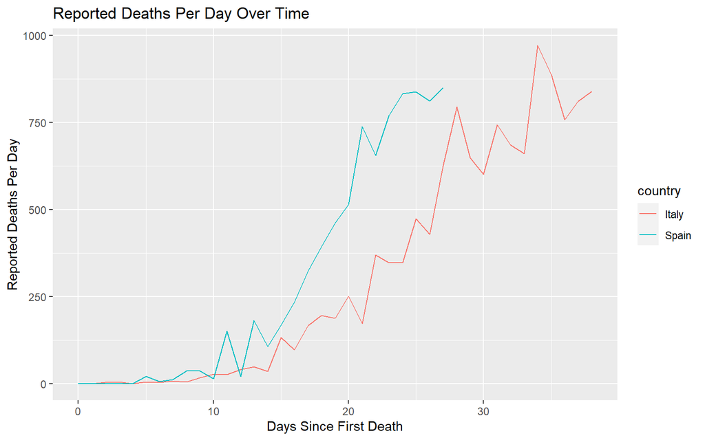

This line graph perfectly illustrates the trend of deaths per day over a period of time in the country of Italy and Spain. The lines are differenciated in color to represent the different countries in order to facilitate comparison. As shown, Italy had an average of 319 in deaths while Spain had an average of 292 in deaths. As shown, Italy had the most deaths with 971 while Spain had 849.

# Question 4

## What is the estimated price elasticity of demand for milk? (Briefly describe what you did)

```
## Estimated K: 133.169
```

```
## Estimated Beta (price elasticity of demand): -1.769
```

In order to find the estimated price elasticity of demand for milk, I used the power-law model where the sales are modeled as a function of price raised to the power of beta.

Following this, I used the ‘nls’ function to conduct a nonlinear least squares regression.

The beta coefficient estimated obtained from the regression represents the price elasticity. As known, a negatiev beta indicates elastic demand; the demand decreases as the prices are raised. In the contrary, a positive beta indicates an inelastic demand; as the price is increased, the demand for the product increases with it (i.e. SUPREME brand).

I extracted the estimated beta coefficient and presented the estimated price elasticity of demand for milk.